# Script 5: Panel Data

Script 5 Spring 2025

# Recap

## Omitted variable bias

Using panel data helps us partly circumvent the issue of *omitted variable bias*, rather than controlling for all potential time-invariant confounders and/or general time trends. We can simply include fixed effects that capture all of these confounders - whether observed or unobserved.

## Time-fixed effects

We know that bias can come from variables that change over time across all units, i.e., general time trends. To minimise bias from these factors, we can include in our model time-effect controls for any common impact that affects all units. Put differently, time-fixed effects are time-specific factors that affect all entities at the same point in time but evolve over time.

## Entity/Unit-fixed effects

A model with unit-fixed effects is a model to which we have added a dummy variable for every unit (county, individual, or state, for instance). By adding these to our model, we control for all differences between units that do not change over time. Unit fixed effects are essentially factors that change from one unit to another, but remain constant over time - this includes all time-invariant unobserved (and, importantly, unobservable) heterogeneity. Put differently, entity or unit-fixed effects are factors that are constant over time, but vary across entities.

The coefficient of each dummy variable shifts the intercept, but does not affect the slope.

$$Y_{i,t} = \beta_1 X_{i,t} + \alpha_i +
\mu_{i,t}$$

## Two-way fixed effects

We can combine both time and unit fixed effects in a single model. These models are referred to as *two-way fixed effects* models. By including both fixed effects we are reducing bias that comes from:

- Factors that are constant (time-invariant), but differ across each unit.
- Factor that vary over time, but affect all units at the same time.

## Diagnosis Test and Standard errors

Using panel data we cannot assume that regression errors are independent of each other. Indeed, standard errors are likely correlated within the same unit or the same year. Therefore, we need to cluster standard errors to adjust/account for this correlation. Using *Clustered standard errors* we allow for heteroskedasticity and autocorrelation within an entity [or time period], but treat the errors as uncorrelated across entities [or time period].

**Before starting this seminar**

1. Create a folder called “script5”
2. Download the data (you can use this button or the one at the top, or read csv files directly from github):
3. Open an R script (or Markdown file) and save it in our “script5” folder.
4. Set your working directory using the setwd() function or by clicking on “More“. For example *setwd(“~/Desktop/Causal Inference/2025/Script5”)*
5. Let’s install an load the packages that we will be using in this script:

```r
library(jtools) # generate plots with regression coefficients
library(stargazer) # generate formated regression tables
library(texreg) # generate formatted regression tables
library(tidyverse) # to conduct some tidy operations
library(ggplot2) # to generate plots
library(plm) # conduct one-way and two-way fixed effects
library(estimatr) #  to conduct ols and provides robust standard errors
library(lmtest) # calculates the variance-covariance matrix to be clustered by group.
library(sandwich) # to calculate heteroscedasticity-Consistent Covariance Matrix Estimation
library(haven) # upload dta files
```

# Seminar Overview

In this **seminar**, we will cover the following topics:  
1. Conduct a time fixed effects model using the `lm()` function  
2. Conduct a time and unit fixed model using the `lm()` function  
3. Conduct a time fixed effects model using the `plm()` function  
4. Conduct a time and unit fixed effect model using the `plm()` function.  
4. Correct standard errors obtained from the `plm()` function.  
5. Conduct a *Hausmann test* and *F-test*

## The Republicans Should Pray for Rain: Weather, Turnout, and Voting in U.S. Presidential Elections

Today, we will work with data from a paper by Gomez et al called [**The Republicans Should Pray for Rain: Weather, Turnout, and Voting in U.S. Presidential Elections**](https://www.journals.uchicago.edu/doi/full/10.1111/j.1468-2508.2007.00565.x?casa_token=-SZBcnHfPM0AAAAA%3AFv-HgCaKgM9wni5evtR3releVKaOXntjUiSyCvtAYTlNnCb01bgizdZOnV_gxGC5htOzNtjg-IS6). In this paper, Gomez et al seek to answer the following question: *Does bad weather affect turnout?* To address this question, they looked at 14 U.S presidential elections. Using GIS interpolations and weather data from 22,000 U.S weather stations, they provide election day estimates of rain and snow at the county level.

Their data consists of over 3,000 counties in the continental United States for each presidential election from 1948 to 2000. The meteorological variables were drawn from the National Climatic Data Center that contained day data report of various measures of the day’s weather, including rainfall and snow, for over 20,000 weather stations. In total the authors collected up to 43,340 observations (N = 3,115, max, and T = 14 elections).

The authors’ main outcome of interest is vote turnout at the county level. The authors find that rain significantly reduces voter participation by a rate of just less than 1%-points per inch. Meanwhile, an inch of snowfall decreases turnout by almost .5%-points. The authors also find that poor weather benefits Republicans.

The main “treatment” variable of this study is estimated rainfall and snowfall measured in inches (1 in = 2,54 cm). The authors used two alternative measures of weather. First, they calculated the normal (average) rainfalls and snowfalls for each county using data from the 1948-2000 time span. Then, they subtracted the appropriate daily normal value from the rainfall or snowfall estimated to have occurred on each election day under analysis.

The authors control for a number of socio-economic factors that are associated with voter turnout such as *High School Graduates* in the county, *median household income*, and how *rural* the county is.

The authors find that when measured as deviations from their normal values, rain and snow elicit a negative and statistically significant effect on voter turnout. Thus, evidence supports the claim that bad weather lowers voters turnout. The authors also find that when rain and snow increase above their local election day normal, the vote share of Republican presidential candidates increases.

A description of some of the variables that we will use today is below:

| Variable | Description |
| --- | --- |
| `Year` | Election Year |
| `State` | State name |
| `County` | County name |
| `FIPS_County` | County id |
| `Turnout` | Turnout in a presidential election as a percentage of voting-age population |
| `Rain` | GIS rainfall estimate |
| `Snow` | GIS snowfall estimate |
| `Rain_Dev` | Deviation from normal rainfall |
| `Snow_Dev` | Deviation from normal snowfall |
| `GOPVoteShare` | Republican Candidate’s Vote Share |
| `PcntBlack` | Estimated percentage of Black population |
| `ZPcntHSGrad` | Estimated percentage high school grads, standarised by years at the county level |
| `FarmsPerCap` | Farms per capita |
| `Unemploy` | Estimated Unemployment Rate |
| `AdjIncome` | CPI Adj Median Household Income (1982-84=100), in 10000s |
| `Closing` | length of time between date voter must register and election day |
| `Literacy` | Literacy test |
| `Poll Tax` | Poll tax |
| `Yr52` | Dummy election 1952 |
| `Yr56` | Dummy election 1956 |
| `Yr..` | Dummy election … |
| `Yr2000` | Dummy election 2000 |

Now let’s load the data. There are two ways to do this:

You can load the dataset from your laptop using the `read_dta()` function. We will call this data frame **weather**.

```r
# Set your working directory
#setwd("~/Desktop/Causal Inference/2025/Script5")
#
#setwd("/cloud/project")
```

Or you can download the data from the course website from following url: https://github.com/bayreuth-politics/CI25/raw/main/docs/data/Weather_publicfile.dta.

Let us start with a few descriptive statistics to become familiar with the data. First, as always, we use the `head()` function to get an impression of the data

```r
head(weather)
```

```
  Year   State  County FIPS_County  Turnout Turnout_Lag GOPVoteShare PcntBlack
1 1948 ALABAMA AUTAUGA        1001 12.87726    13.06288     8.553655  47.00900
2 1952 ALABAMA AUTAUGA        1001 23.53037    12.87726    34.098790  45.16853
3 1956 ALABAMA AUTAUGA        1001 23.08282    23.53037    37.472670  43.61412
4 1960 ALABAMA AUTAUGA        1001 26.49146    23.08282    43.342130  42.09053
5 1964 ALABAMA AUTAUGA        1001 29.25427    26.49146    85.809250  33.70723
6 1968 ALABAMA AUTAUGA        1001 57.02074    29.25427     7.787201  27.56027
  ZPcntHSGrad FarmsPerCap Unemploy AdjIncome Closing Property Literacy PollTax
1  -1.0891030   0.0882406 5.642747 0.3612264      10        0        1       1
2  -0.9176651   0.0861690 3.272751 0.6096017      10        0        0       1
3  -0.8140256   0.0535593 3.636375 0.8677695      10        0        0       1
4  -0.7632608   0.0217194 4.000000 1.1244930      10        0        0       1
5  -0.4192493   0.0221520 3.480000 1.6020970      10        0        0       0
6  -0.1011990   0.0224998 2.960000 1.8978450      10        0        0       0
  Motor GubElection SenElection Yr52 Yr56 Yr60 Yr64 Yr68 Yr72 Yr76 Yr80 Yr84
```

[output cut: 20 more lines]

Now, let’s have a look at the number of elections that are included in the data set. We know that the authors are looking at presidential elections, so each unique year in the data can cover only one and the same presidential election. We use the `unique()` command to retrieve unique values of the `Year` variable. Then, you can use the `length()` command to display the number of unique values.

```r
# Retrieving unique values of the variable
unique(weather$Year)
```

```
 [1] 1948 1952 1956 1960 1964 1968 1972 1976 1980 1984 1988 1992 1996 2000
```

```r
# Retrieving the number of the unique values of the variable.
length(unique(weather$Year))
```

```
[1] 14
```

So the data set covers 14 different presidential elections - as the `unique()` command shows us, these are all elections that took place between 1948 and 2000. Let’s do the same now for the number of states.

**Exercise 1: How many US states are covered by the data - which ones are missing?**

**Reveal Answer**

```r
# Retrieving the number of the unique values of the variable.
length(unique(weather$State))
```

```
[1] 48
```

```r
# Retrieving unique values of the variable
unique(weather$State)
```

```
 [1] "ALABAMA"        "ARIZONA"        "ARKANSAS"       "CALIFORNIA"
 [5] "COLORADO"       "CONNECTICUT"    "DELAWARE"       "FLORIDA"
 [9] "GEORGIA"        "IDAHO"          "ILLINOIS"       "INDIANA"
[13] "IOWA"           "KANSAS"         "KENTUCKY"       "LOUISIANA"
[17] "MAINE"          "MARYLAND"       "MASSACHUSETTS"  "MICHIGAN"
[21] "MINNESOTA"      "MISSISSIPPI"    "MISSOURI"       "MONTANA"
[25] "NEBRASKA"       "NEVADA"         "NEW HAMPSHIRE"  "NEW JERSEY"
[29] "NEW MEXICO"     "NEW YORK"       "NORTH CAROLINA" "NORTH DAKOTA"
[33] "OHIO"           "OKLAHOMA"       "OREGON"         "PENNSYLVANIA"
[37] "RHODE ISLAND"   "SOUTH CAROLINA" "SOUTH DAKOTA"   "TENNESSEE"
[41] "TEXAS"          "UTAH"           "VERMONT"        "VIRGINIA"
[45] "WASHINGTON"     "WEST VIRGINIA"  "WISCONSIN"      "WYOMING"
```

The data cover 48 US states, so two are missing. We can see that the data cover all contiguous US states - the two missing ones are Alaska and Hawaii. Is there a reason to exclude them?

There is! Alaska and Hawaii joined the Union only in 1959 - so the authors would have had shorter time-series for these two states.

## The Times they are a changin’: Pooled OLS v Fixed Effects

Let’s start by paying attention to the temporal dimension of our voting data. Conventional wisdom has it that each and every election is different. Accordingly, we want to acknowledge these differences across elections and take them into account when estimating our models.

Let’s first have a look at the broad picture by plotting the outcome of interest across time. We can use the `boxplot()` function to this. The syntax is the following `boxplot(Y ~ X, data= data, xlab="X Label", ylab="Y Label")`.

**Exercise 2: Plot `GOPVoteShare` over time**

**Reveal Answer**

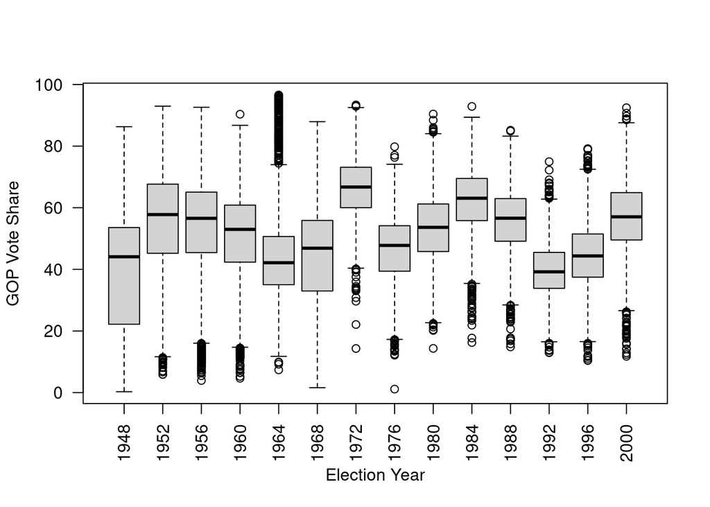

```r
boxplot(GOPVoteShare ~ Year,
        data = weather,
        xlab = "Election Year",
        ylab = "GOP Vote Share",
        las = 2) # This argument rotates the axis labels
```

The vote share cast for the GOP varies widely. Note that the data set includes an observation for each *county*. The box indicates the interquartile range (i.e. the difference between the third and first quartile of data points) and the solid lines the median value for each year. There are meaningful differences: Note how GOP vote share is larger in 1972, when McGovern (ever heard of him?) had no chance against Nixon. Importantly, we still see a rather broad range of GOP vote shares - this is the variation introduced by individual counties and their specifics. Considering only temporal differences here, we do not distinguish any other effects.

Let’s now run a simple OLS model without considering any variation introduced by temporal differences or unit (i.e. county) specifics. Such a model is called *pooled OLS* as we simply pool all observations in our data set to estimate a coefficient. By design, all observations are considered to be independent of each other in such model.

**Exercise 3: Regress `GOPVoteShare` on `Rain`**

Estimate two models: First, a simple bivariate model and second a model that includes important covariates: `PcntBlack`, `ZPcntHSGrad`, `FarmsPerCap`, `AdjIncome` and `Literacy`. Interpret your model estimates.

**Reveal Answer**

```r
# Bivariate pooled OLS
ols_bivariate <- lm(GOPVoteShare ~ Rain, data=weather)
summary(ols_bivariate)
```

```
Call:
lm(formula = GOPVoteShare ~ Rain, data = weather)

Residuals:
    Min      1Q  Median      3Q     Max
-50.845  -9.826   1.035  10.957  45.718

Coefficients:
            Estimate Std. Error t value Pr(>|t|)
(Intercept) 50.87158    0.07924 642.023   <2e-16 ***
Rain         0.50357    0.30494   1.651   0.0987 .
---
Signif. codes:  0 '***' 0.001 '**' 0.01 '*' 0.05 '.' 0.1 ' ' 1

Residual standard error: 15.55 on 43338 degrees of freedom
Multiple R-squared:  6.292e-05, Adjusted R-squared:  3.985e-05
F-statistic: 2.727 on 1 and 43338 DF,  p-value: 0.09867
```

```r
# Multivariate pooled OLS
ols_covariates <- lm(GOPVoteShare ~ Rain + PcntBlack + ZPcntHSGrad + FarmsPerCap + AdjIncome + Literacy, data=weather)
summary(ols_covariates)
```

```
Call:
lm(formula = GOPVoteShare ~ Rain + PcntBlack + ZPcntHSGrad +
    FarmsPerCap + AdjIncome + Literacy, data = weather)

Residuals:
    Min      1Q  Median      3Q     Max
-52.955  -9.581   0.249   9.806  69.800

Coefficients:
            Estimate Std. Error t value Pr(>|t|)
(Intercept) 45.75850    0.33286 137.469  < 2e-16 ***
Rain         1.08860    0.27941   3.896 9.79e-05 ***
PcntBlack   -0.23050    0.00563 -40.940  < 2e-16 ***
ZPcntHSGrad  2.01974    0.08536  23.661  < 2e-16 ***
FarmsPerCap 43.40966    1.96753  22.063  < 2e-16 ***
AdjIncome    3.00524    0.13687  21.956  < 2e-16 ***
Literacy    -3.97069    0.24021 -16.530  < 2e-16 ***
---
Signif. codes:  0 '***' 0.001 '**' 0.01 '*' 0.05 '.' 0.1 ' ' 1

Residual standard error: 14.21 on 43333 degrees of freedom
Multiple R-squared:  0.1645,    Adjusted R-squared:  0.1644
F-statistic:  1422 on 6 and 43333 DF,  p-value: < 2.2e-16
```

The bivariate model estimates a - hardly significant - association between rain and GOP vote share of 0.5%-points per inch. As we know, however, such bivariate association does not account for several other effects. Indeed, all covariates included in the multivariate pooled OLS are highly correlated with GOP vote share - and the estimate of rain on election day doubles to about 1%-point in the multivariate model.

Let’s now move away from the pooled - or naive - OLS model. We know that despite accounting for the covariates, the multivariate model does not account for variance from two important sources: (i) general temporal development, (ii) unit-specific time-invariant variance. In a first step, we account for the former. Let’s see how acknowledging general election effects changes our estimate.

In other words, we will now estimate a **fixed-effects model**. You can use the `lm()` function to include time-fixed effects. If you add the `Year` variable as factorised variable, a dummy variable for each year is added to the regression equation. In other words, we allow each presidential election to have a different (non-random!) intercept but estimate a single slope for the independent variables.

**Exercise 4: Estimate the same bivariate and multivariate models as above including time-fixed effects.**

**Reveal Answer**

Note that this is not the same as simply adding the `Year` variable as an independent variable. If you did the latter, - with `Year` being a continuous variable - R would simply understand it to be a single, general and *continuous* time trend.

```r
# Bivariate time FE
FE_bivariate <- lm(GOPVoteShare ~ Rain + factor(Year), data=weather)
summary(FE_bivariate)
```

```
Call:
lm(formula = GOPVoteShare ~ Rain + factor(Year), data = weather)

Residuals:
    Min      1Q  Median      3Q     Max
-52.403  -7.759   0.849   8.815  52.372

Coefficients:
                 Estimate Std. Error t value Pr(>|t|)
(Intercept)       39.2568     0.2465 159.232  < 2e-16 ***
Rain              -1.0548     0.2845  -3.708 0.000209 ***
factor(Year)1952  15.9501     0.3442  46.340  < 2e-16 ***
factor(Year)1956  14.4377     0.3411  42.322  < 2e-16 ***
factor(Year)1960  11.3954     0.3425  33.275  < 2e-16 ***
factor(Year)1964   4.9604     0.3438  14.428  < 2e-16 ***
factor(Year)1968   4.5954     0.3428  13.407  < 2e-16 ***
factor(Year)1972  27.4617     0.3407  80.594  < 2e-16 ***
factor(Year)1976   7.1658     0.3439  20.837  < 2e-16 ***
factor(Year)1980  14.3616     0.3436  41.794  < 2e-16 ***
factor(Year)1984  23.2201     0.3428  67.744  < 2e-16 ***
factor(Year)1988  16.7244     0.3424  48.841  < 2e-16 ***
factor(Year)1992   0.7715     0.3396   2.272 0.023110 *
factor(Year)1996   5.5399     0.3422  16.187  < 2e-16 ***
factor(Year)2000  17.9530     0.3406  52.704  < 2e-16 ***
---
Signif. codes:  0 '***' 0.001 '**' 0.01 '*' 0.05 '.' 0.1 ' ' 1

Residual standard error: 13.36 on 43325 degrees of freedom
Multiple R-squared:  0.2621,    Adjusted R-squared:  0.2618
F-statistic:  1099 on 14 and 43325 DF,  p-value: < 2.2e-16
```

```r
# Multivariate time FE
FE_covariates <- lm(GOPVoteShare ~ Rain + PcntBlack + ZPcntHSGrad + FarmsPerCap + AdjIncome + Literacy  + factor(Year), data=weather)
summary(FE_covariates)
```

```
Call:
lm(formula = GOPVoteShare ~ Rain + PcntBlack + ZPcntHSGrad +
    FarmsPerCap + AdjIncome + Literacy + factor(Year), data = weather)

Residuals:
    Min      1Q  Median      3Q     Max
-49.622  -7.631   0.325   7.743  73.060

Coefficients:
                  Estimate Std. Error t value Pr(>|t|)
(Intercept)      39.269963   0.344545 113.976   <2e-16 ***
Rain              0.114292   0.255610   0.447   0.6548
PcntBlack        -0.238743   0.004769 -50.056   <2e-16 ***
ZPcntHSGrad       2.924763   0.087118  33.572   <2e-16 ***
FarmsPerCap      35.762215   1.720000  20.792   <2e-16 ***
AdjIncome         0.140178   0.191640   0.731   0.4645
Literacy         -2.333959   0.213516 -10.931   <2e-16 ***
factor(Year)1952 16.099061   0.311004  51.765   <2e-16 ***
factor(Year)1956 15.075127   0.314584  47.921   <2e-16 ***
factor(Year)1960 12.700441   0.324737  39.110   <2e-16 ***
factor(Year)1964  5.925331   0.349124  16.972   <2e-16 ***
factor(Year)1968  4.925047   0.365851  13.462   <2e-16 ***
factor(Year)1972 26.974076   0.416674  64.737   <2e-16 ***
factor(Year)1976  7.240351   0.423082  17.113   <2e-16 ***
factor(Year)1980 14.700643   0.392609  37.443   <2e-16 ***
factor(Year)1984 23.479995   0.394124  59.575   <2e-16 ***
factor(Year)1988 16.906547   0.410397  41.196   <2e-16 ***
factor(Year)1992  0.952088   0.393233   2.421   0.0155 *
factor(Year)1996  6.036349   0.389940  15.480   <2e-16 ***
factor(Year)2000 18.317105   0.384949  47.583   <2e-16 ***
---
Signif. codes:  0 '***' 0.001 '**' 0.01 '*' 0.05 '.' 0.1 ' ' 1

Residual standard error: 11.99 on 43320 degrees of freedom
Multiple R-squared:  0.406, Adjusted R-squared:  0.4058
F-statistic:  1558 on 19 and 43320 DF,  p-value: < 2.2e-16
```

Do you notice the vast differences in our estimated effect of `Rain`? In the bivariate FE model, the estimated effect is *negative*, so one inch of rain would be associated with a 1%-point decrease in GOP vote share. Once we control for the same set of covariates as above, the model estimates that an increase in one unit of`Rain` is not associated with GOP vote share at all! As you see, we can estimate all kinds of models - it’s our responsibility to make sure to actually run a meaningful that is able to estimate the effect we want to get at.

Let’s pause a moment to make sure we grasp the difference between a pooled OLS and the FE estimator. Simply speaking, the pooled OLS considers each observation but does not differentiate them in any particular way. Thus, the bivariate model simply estimates the mathematical association between the two variables, using all data points:

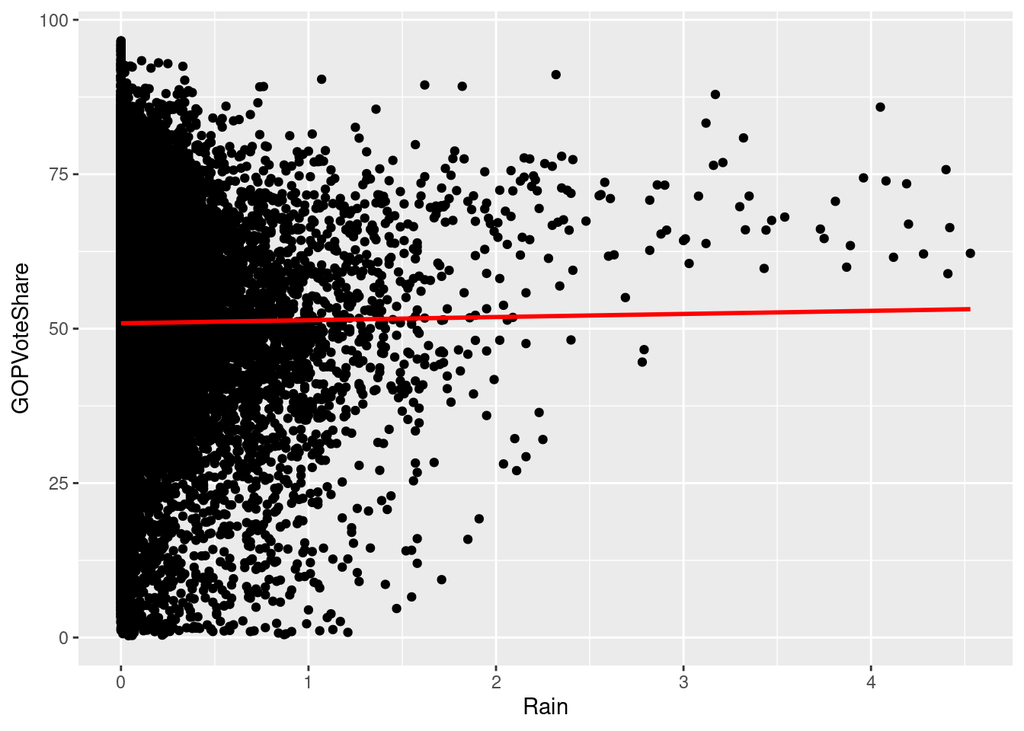

```r
require(modelr)
require(ggplot2)
grid <- data.frame(Intercept=1, Rain=seq_range(weather$Rain, 10))
grid$pred <- predict(ols_bivariate,grid)
ggplot(weather, aes(Rain)) +
  geom_point(aes(y = GOPVoteShare)) +
  geom_line(aes(y = pred), data = grid, colour = "red", size = 1)
```

The logic of the FE estimator is different, however. This estimator looks at and compares data points *within* a certain period. It estimates a single coefficient (or slope) for independent variables, but allows each period to have an individual intercept, thus capturing general time trends that affect all units. Let’s look at the coefficient of `Rain` in the bivariate FE model now:

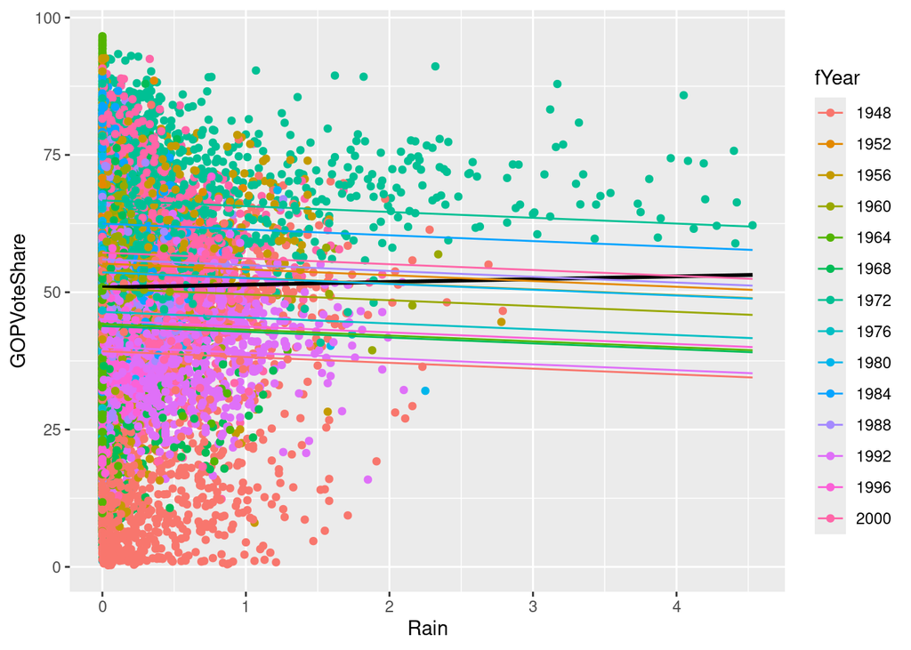

```r
weather$fYear <- factor(weather$Year) # Creating a factor variable makes it easier to plot


grid_fixdum <- expand(data.frame(Intercept=1, Rain=seq_range(weather$Rain, 14), Year=unique(weather$fYear)),
                      Rain, Year)
grid_fixdum$pred <- predict(FE_bivariate,grid_fixdum)
ggplot(weather, aes(Rain)) +
  geom_point(aes(y = GOPVoteShare, colour=fYear)) +
  geom_smooth(aes(y = GOPVoteShare), method='lm', se=FALSE, colour="black")+
  geom_line(data=grid_fixdum, aes(x=Rain, y=pred, colour=Year))
```

In fact, looking only at the effects *within* `Years`, we can see that the aggregate slope is even slightly negative!

Even with our FE estimates, however, there is an important problem. Using the `lm()` command, R estimates the time dummies as additional variables. This affects the measures of uncertainty and, therefore, statistical significance as observations within the same year are not independent. In fact, we want to estimate FE models precisely because we have reason to believe that they are not independent of each other.

To adjust for this dependence of observations, we must calculate **robust - or clustered or panel-corrected - standard errors**. *This is important and should always be done when estimating FE models - otherwise standard errors will be (heavily) biased. In turn, this would mean we make wrong inferences.*

Luckily, we can easily adjust standard errors, either manually using special packages such as the `sandwich` package or automatically as part of the regression estimation. To do the latter, we can use the `lm_robust()` command from the `estimatr` package. It’s syntax is similar to the general `lm()` command, but it allows you to simply specify fixed effects by adding a `fixed_effects=` argument, followed by the variable indicating FE. Robust standard errors are automatically calculated when you use that function.

**Exercise 5: Estimate the same time-FE models as above with robust standard errors using the `lm_robust()` function.**

**Reveal Answer**

```r
require(estimatr)

# Bivariate time-FE with  roust SEs
FE_robust_bivariate <- lm_robust(GOPVoteShare ~ Rain, fixed_effects= factor(Year), data=weather)
summary(FE_robust_bivariate)
```

```
Call:
lm_robust(formula = GOPVoteShare ~ Rain, data = weather, fixed_effects = factor(Year))

Standard error type:  HC2

Coefficients:
     Estimate Std. Error t value  Pr(>|t|) CI Lower CI Upper    DF
Rain   -1.055      0.256   -4.12 3.798e-05   -1.557   -0.553 43325

Multiple R-squared:  0.2621 ,   Adjusted R-squared:  0.2618
Multiple R-squared (proj. model):  0.0003172 ,  Adjusted R-squared (proj. model):  -5.8e-06
F-statistic (proj. model): 16.97 on 1 and 43325 DF,  p-value: 3.798e-05
```

```r
# Multivariate time-FE with  roust SEs
FE_robust_covariates <- lm_robust(GOPVoteShare ~ Rain + PcntBlack + ZPcntHSGrad + FarmsPerCap + AdjIncome + Literacy, fixed_effects= factor(Year), data=weather)
summary(FE_robust_covariates)
```

```
Call:
lm_robust(formula = GOPVoteShare ~ Rain + PcntBlack + ZPcntHSGrad +
    FarmsPerCap + AdjIncome + Literacy, data = weather, fixed_effects = factor(Year))

Standard error type:  HC2

Coefficients:
            Estimate Std. Error  t value   Pr(>|t|) CI Lower CI Upper    DF
Rain          0.1143   0.255639   0.4471  6.548e-01  -0.3868   0.6153 43320
PcntBlack    -0.2387   0.005784 -41.2799  0.000e+00  -0.2501  -0.2274 43320
ZPcntHSGrad   2.9248   0.092533  31.6078 8.493e-217   2.7434   3.1061 43320
FarmsPerCap  35.7622   1.732838  20.6379  3.562e-94  32.3658  39.1586 43320
AdjIncome     0.1402   0.187772   0.7465  4.553e-01  -0.2279   0.5082 43320
Literacy     -2.3340   0.270200  -8.6379  5.918e-18  -2.8636  -1.8044 43320

Multiple R-squared:  0.406 ,    Adjusted R-squared:  0.4058
Multiple R-squared (proj. model):  0.1953 , Adjusted R-squared (proj. model):  0.195
F-statistic (proj. model):  1343 on 6 and 43320 DF,  p-value: < 2.2e-16
```

This is better - now we have unbiased SEs. Note that calculating robust standard errors does not affect the estimates - but it does change SEs and all statistics that are dependent on them. Since we calculate models in order to make causal statements about effects, it is absolutely crucial to make sure these statistics are unbiased.

**Exercise 6: Display the regression output of all six models in a single table. Interpret the models.**

**Reveal Answer**

```r
require(texreg)
# This is one possible option, there are many others.

screenreg(l=list(ols_bivariate, ols_covariates, FE_bivariate, FE_covariates, FE_robust_bivariate, FE_robust_covariates), include.ci =  FALSE,           custom.header = list("Pooled OLS" = 1:2, "Time FE" = 3:4, "Robust Time FE" = 5:6),
          omit.coef = "(Intercept)")
```

```
=================================================================================================
                         Pooled OLS                  Time FE                 Robust Time FE
                  -----------------------  --------------------------  --------------------------
                  Model 1    Model 2       Model 3       Model 4       Model 5       Model 6
-------------------------------------------------------------------------------------------------
Rain                  0.50       1.09 ***     -1.05 ***      0.11         -1.05 ***      0.11
                     (0.30)     (0.28)        (0.28)        (0.26)        (0.26)        (0.26)
PcntBlack                       -0.23 ***                   -0.24 ***                   -0.24 ***
                                (0.01)                      (0.00)                      (0.01)
ZPcntHSGrad                      2.02 ***                    2.92 ***                    2.92 ***
                                (0.09)                      (0.09)                      (0.09)
FarmsPerCap                     43.41 ***                   35.76 ***                   35.76 ***
                                (1.97)                      (1.72)                      (1.73)
AdjIncome                        3.01 ***                    0.14                        0.14
                                (0.14)                      (0.19)                      (0.19)
Literacy                        -3.97 ***                   -2.33 ***                   -2.33 ***
                                (0.24)                      (0.21)                      (0.27)
factor(Year)1952                              15.95 ***     16.10 ***
                                              (0.34)        (0.31)
factor(Year)1956                              14.44 ***     15.08 ***
                                              (0.34)        (0.31)
factor(Year)1960                              11.40 ***     12.70 ***
                                              (0.34)        (0.32)
factor(Year)1964                               4.96 ***      5.93 ***
                                              (0.34)        (0.35)
factor(Year)1968                               4.60 ***      4.93 ***
                                              (0.34)        (0.37)
factor(Year)1972                              27.46 ***     26.97 ***
                                              (0.34)        (0.42)
factor(Year)1976                               7.17 ***      7.24 ***
                                              (0.34)        (0.42)
factor(Year)1980                              14.36 ***     14.70 ***
                                              (0.34)        (0.39)
factor(Year)1984                              23.22 ***     23.48 ***
                                              (0.34)        (0.39)
factor(Year)1988                              16.72 ***     16.91 ***
                                              (0.34)        (0.41)
factor(Year)1992                               0.77 *        0.95 *
                                              (0.34)        (0.39)
factor(Year)1996                               5.54 ***      6.04 ***
                                              (0.34)        (0.39)
factor(Year)2000                              17.95 ***     18.32 ***
                                              (0.34)        (0.38)
-------------------------------------------------------------------------------------------------
R^2                   0.00       0.16          0.26          0.41          0.26          0.41
Adj. R^2              0.00       0.16          0.26          0.41          0.26          0.41
Num. obs.         43340      43340         43340         43340         43340         43340
RMSE                                                                      13.36         11.99
=================================================================================================
*** p < 0.001; ** p < 0.01; * p < 0.05
```

```r
## drop or amend the 'include.ci' option to display CIs instead of SEs - which is default for lm_robust
```

Pay attention to the significant differences between the OLS models and the FE models. Based on the pooled OLS model, we would have thought that `rain` is associated with an increase in GOP vote share once we control for covariates. However, doing so does not account for temporal changes and is based on comparisons across different elections. In other words, a pooled OLS compares different observations from different points in time of different units to each other.

Accounting for time by calculating time-FE models changes the picture. While we find a bivariate relationship, there is no significant association between `Rain` (or `AdjIncome`) and `GOPVoteShare` once we include a list of (time-variant) covariates into our model. Note that in the FE models we are estimating effects of `Rain` within each individual election year and do *not* simply compare observations from different election years to each other.

### PLM Function

Rather than using `lm()` or `lm_robust()`, we can use the `plm()` function from the `plm` package that allows conducting unit and time fixed effect models. The syntax is quite simple: `plm(formula, effect = "", model = "", index = c("unit", "year"), data = data)`. The `effect` argument sets what type of model you want to run, some of the options are “individual”, which is unit-fixed effect, “time” for time-fixed effects, and “twoways” for two-way fixed effects. The `model` argument determines the estimation method. If you want to calculate the coefficients by demeaning both dependent and independent variables, and then calculate estimates using deviations from the mean, you need to set `model` argument equal to `"within"` - which corresponds to the fixed effects methods we discussed in the lecture. What essentially happens with the “within” estimation is that group-specific mean values are subtracted from the dependent variable and explanatory variables, which effectively ‘removes’ unit-specific and time-specific effects. If you want to estimate the coefficients using the first difference estimator, you can set the `model` argument equal to `"fd"`. The `index` argument tells the function what is the structure of the data i.e. what variable contains the time periods and what variable contains the units, so we need to tell the function what variable is the entity identifiers and the time identifier.

Now, let’s estimate this using a fixed-effects model, using the `plm()` function. Let’s start conducting time FE models for the `Turnout` variable for both “treatment” variables `Rain_Dev` and `Snow_Dev`. Let’s estimate the simplest version without covariates.

**Exercise 7: Run time FE models for both weather variables (`Rain_Dev` and `Snow_Dev` in separate models), set `effects` equal to “time”. Set the model argument equal to `"within"`, and set the `index` argument equal to `c("FIPS_County", "Year")`. Store the output of your time FE model into an object and then use the `summary()` to check for your results. Interpret the results of both estimations.**

**Reveal Answer**

```r
turnout_time_plm_rain <- plm(Turnout ~ Rain_Dev, effect = "time", model = "within", index = c("FIPS_County", "Year"), data = weather)
summary(turnout_time_plm_rain)
```

```
Oneway (time) effect Within Model

Call:
plm(formula = Turnout ~ Rain_Dev, data = weather, effect = "time",
    model = "within", index = c("FIPS_County", "Year"))

Unbalanced Panel: n = 3115, T = 1-14, N = 43340

Residuals:
    Min.  1st Qu.   Median  3rd Qu.     Max.
-59.7566  -8.8644   1.1638   9.8351  51.2478

Coefficients:
         Estimate Std. Error t-value  Pr(>|t|)
Rain_Dev   2.1607     0.3053  7.0772 1.493e-12 ***
---
Signif. codes:  0 '***' 0.001 '**' 0.01 '*' 0.05 '.' 0.1 ' ' 1

Total Sum of Squares:    8575500
Residual Sum of Squares: 8565600
R-Squared:      0.0011547
Adj. R-Squared: 0.00083197
F-statistic: 50.0866 on 1 and 43325 DF, p-value: 1.4934e-12
```

```r
turnout_time_plm_snow <- plm(Turnout ~ Snow_Dev, effect = "time", model = "within", index = c("FIPS_County", "Year"), data = weather)
summary(turnout_time_plm_snow)
```

```
Oneway (time) effect Within Model

Call:
plm(formula = Turnout ~ Snow_Dev, data = weather, effect = "time",
    model = "within", index = c("FIPS_County", "Year"))

Unbalanced Panel: n = 3115, T = 1-14, N = 43340

Residuals:
    Min.  1st Qu.   Median  3rd Qu.     Max.
-59.8279  -8.8736   1.1604   9.8141  50.9186

Coefficients:
         Estimate Std. Error t-value  Pr(>|t|)
Snow_Dev   1.0105     0.2592  3.8984 9.697e-05 ***
---
Signif. codes:  0 '***' 0.001 '**' 0.01 '*' 0.05 '.' 0.1 ' ' 1

Total Sum of Squares:    8575500
Residual Sum of Squares: 8572400
R-Squared:      0.00035066
Adj. R-Squared: 2.7633e-05
F-statistic: 15.1976 on 1 and 43325 DF, p-value: 9.697e-05
```

We find that a unit increase on deviation of rainfall from a “normal” election day weather is associated with a `2.16` increase in turnout, once we include time-fixed effects. The effect of snowfalls seems to be smaller at `1.0105`. Note that the results of these bivariate models are in the opposite direction of what the authors found in their study, and note that here we only account for general time trends. Let’s do the same but now let’s look at vote share for Republicans.

**Exercise 8: Run a time FE model using the `plm()` function, but look at the effect of rainfall and snowfall on the vote share for Republicans (`GOPVoteShare`). Remember to set the `effect` argument equal to `"time"` and time `model` argument equal to `within`. Store the output from the `plm()` function into an object. Use the `summary()` command check the results. Interpret the coefficient from the `Rain_Dev` and `Snow_Dev` “treatment” variables. Do above average rainfalls and snowfalls increase or decrease GOP vote share? Are the results statistically significant?**

**Reveal Answer**

```r
gop_time_plm_rain <- plm(GOPVoteShare ~ Rain_Dev, effect = "time", model = "within", index = c("FIPS_County", "Year"), data = weather)

summary(gop_time_plm_rain)
```

```
Oneway (time) effect Within Model

Call:
plm(formula = GOPVoteShare ~ Rain_Dev, data = weather, effect = "time",
    model = "within", index = c("FIPS_County", "Year"))

Unbalanced Panel: n = 3115, T = 1-14, N = 43340

Residuals:
    Min.  1st Qu.   Median  3rd Qu.     Max.
-51.6679  -7.7675   0.8605   8.7976  52.4383

Coefficients:
         Estimate Std. Error t-value  Pr(>|t|)
Rain_Dev  1.93450    0.28998  6.6712 2.567e-11 ***
---
Signif. codes:  0 '***' 0.001 '**' 0.01 '*' 0.05 '.' 0.1 ' ' 1

Total Sum of Squares:    7735200
Residual Sum of Squares: 7727300
R-Squared:      0.0010262
Adj. R-Squared: 0.00070339
F-statistic: 44.5055 on 1 and 43325 DF, p-value: 2.5669e-11
```

```r
gop_time_plm_snow <- plm(GOPVoteShare ~ Snow_Dev, effect = "time", model = "within", index = c("FIPS_County", "Year"), data = weather)
summary(gop_time_plm_snow)
```

```
Oneway (time) effect Within Model

Call:
plm(formula = GOPVoteShare ~ Snow_Dev, data = weather, effect = "time",
    model = "within", index = c("FIPS_County", "Year"))

Unbalanced Panel: n = 3115, T = 1-14, N = 43340

Residuals:
     Min.   1st Qu.    Median   3rd Qu.      Max.
-52.10854  -7.77081   0.85456   8.81168  52.38089

Coefficients:
         Estimate Std. Error t-value Pr(>|t|)
Snow_Dev 0.017652   0.246213  0.0717   0.9428

Total Sum of Squares:    7735200
Residual Sum of Squares: 7735200
R-Squared:      1.1864e-07
Adj. R-Squared: -0.00032302
F-statistic: 0.00514001 on 1 and 43325 DF, p-value: 0.94285
```

We find that a unit increase in the deviation from the average rainfalls on election day is associated with an increase in vote share for the Republicans by 1.93 percent, once we control for time-FE. Meanwhile, a unit increase in the deviation from the average snowfall is associated with a 0.01 increase in vote share for Republicans. However, this last result is not statistically significant. These results are more in line with what the authors found in their study.

### Unit-FE

With the `plm()` function we can also conduct unit-FE. We only need to do is to set the `effect` argument equal to `"individual"`. Let’s do that:

**Exercise 9: Conduct a unit FE looking at the effect of weather on voter turnout (`Turnout`) and vote share for Republicans (`GOPVoteShare`). Use both measures of weather `Rain_Dev` and `Snow_Dev`. Store the output of your panel data estimations into an object and use the `summary()` function to check the results.**

**Reveal Answer**

```r
# Turnout - rain
turnout_unit_plm_rain <- plm(Turnout ~ Rain_Dev, effect = "individual", model = "within", index = c("FIPS_County", "Year"), data = weather)
summary(turnout_unit_plm_rain)
```

```
Oneway (individual) effect Within Model

Call:
plm(formula = Turnout ~ Rain_Dev, data = weather, effect = "individual",
    model = "within", index = c("FIPS_County", "Year"))

Unbalanced Panel: n = 3115, T = 1-14, N = 43340

Residuals:
     Min.   1st Qu.    Median   3rd Qu.      Max.
-43.06166  -4.68951   0.27929   5.33676  51.51613

Coefficients:
         Estimate Std. Error t-value  Pr(>|t|)
Rain_Dev -2.68231    0.17749 -15.113 < 2.2e-16 ***
---
Signif. codes:  0 '***' 0.001 '**' 0.01 '*' 0.05 '.' 0.1 ' ' 1

Total Sum of Squares:    3015400
Residual Sum of Squares: 2998400
R-Squared:      0.005646
Adj. R-Squared: -0.071358
F-statistic: 228.392 on 1 and 40224 DF, p-value: < 2.22e-16
```

```r
# Turnout - snow
turnout_unit_plm_snow <- plm(Turnout ~ Snow_Dev, effect = "individual", model = "within", index = c("FIPS_County", "Year"), data = weather)
summary(turnout_unit_plm_snow)
```

```
Oneway (individual) effect Within Model

Call:
plm(formula = Turnout ~ Snow_Dev, data = weather, effect = "individual",
    model = "within", index = c("FIPS_County", "Year"))

Unbalanced Panel: n = 3115, T = 1-14, N = 43340

Residuals:
     Min.   1st Qu.    Median   3rd Qu.      Max.
-44.42899  -4.72004   0.29016   5.32023  51.71578

Coefficients:
         Estimate Std. Error t-value  Pr(>|t|)
Snow_Dev -0.89117    0.16242 -5.4869 4.116e-08 ***
---
Signif. codes:  0 '***' 0.001 '**' 0.01 '*' 0.05 '.' 0.1 ' ' 1

Total Sum of Squares:    3015400
Residual Sum of Squares: 3013100
R-Squared:      0.00074789
Adj. R-Squared: -0.076636
F-statistic: 30.1056 on 1 and 40224 DF, p-value: 4.1161e-08
```

```r
# GOP vote share - rain
gop_unit_plm_rain <- plm(GOPVoteShare ~ Rain_Dev, effect = "individual", model = "within", index = c("FIPS_County", "Year"), data = weather)
summary(gop_unit_plm_rain)
```

```
Oneway (individual) effect Within Model

Call:
plm(formula = GOPVoteShare ~ Rain_Dev, data = weather, effect = "individual",
    model = "within", index = c("FIPS_County", "Year"))

Unbalanced Panel: n = 3115, T = 1-14, N = 43340

Residuals:
     Min.   1st Qu.    Median   3rd Qu.      Max.
-59.21455  -7.53955   0.63525   7.74417  69.37792

Coefficients:
         Estimate Std. Error t-value  Pr(>|t|)
Rain_Dev  4.96120    0.26175  18.954 < 2.2e-16 ***
---
Signif. codes:  0 '***' 0.001 '**' 0.01 '*' 0.05 '.' 0.1 ' ' 1

Total Sum of Squares:    6579300
Residual Sum of Squares: 6521100
R-Squared:      0.0088523
Adj. R-Squared: -0.067904
F-statistic: 359.253 on 1 and 40224 DF, p-value: < 2.22e-16
```

```r
# GOP vote share - snow
gop_unit_plm_snow <- plm(GOPVoteShare ~ Snow_Dev, effect = "individual", model = "within", index = c("FIPS_County", "Year"), data = weather)
summary(gop_unit_plm_snow)
```

```
Oneway (individual) effect Within Model

Call:
plm(formula = GOPVoteShare ~ Snow_Dev, data = weather, effect = "individual",
    model = "within", index = c("FIPS_County", "Year"))

Unbalanced Panel: n = 3115, T = 1-14, N = 43340

Residuals:
     Min.   1st Qu.    Median   3rd Qu.      Max.
-56.68786  -7.68837   0.51442   7.69538  68.74177

Coefficients:
         Estimate Std. Error t-value  Pr(>|t|)
Snow_Dev -1.36523    0.23991 -5.6906 1.274e-08 ***
---
Signif. codes:  0 '***' 0.001 '**' 0.01 '*' 0.05 '.' 0.1 ' ' 1

Total Sum of Squares:    6579300
Residual Sum of Squares: 6574100
R-Squared:      0.00080443
Adj. R-Squared: -0.076575
F-statistic: 32.3834 on 1 and 40224 DF, p-value: 1.2744e-08
```

### Two-Way Fixed Effects

Now that we have conducted time and unit FE separately, but we can conduct a two-way FE model that controls for unit and time FE at the same time. In a two-ways FE model, we are controlling for all unit-specific time-invariant confounders and year-specific confounders that affect all units at the same time. To do this using `plm()` is very simple, we only need to change the `effect` argument and set it equal to `twoways`.

**Exercise 10: Conduct a two-way FE model looking at the effect of weather on voter turnout and GOP vote share. Use both measures of weather `Rain_Dev` and `Snow_Dev`. Set the `effect` argument equal to `"twoways"`. Store the outputs into objects and then use the `summary()` to check the results.**

**Reveal Answer**

```r
# two-way Turnout - rain
turnout_twoway_plm_rain <- plm(Turnout ~ Rain_Dev, effect = "twoways", model = "within", index = c("FIPS_County", "Year"), data = weather)
summary(turnout_twoway_plm_rain)
```

```
Twoways effects Within Model

Call:
plm(formula = Turnout ~ Rain_Dev, data = weather, effect = "twoways",
    model = "within", index = c("FIPS_County", "Year"))

Unbalanced Panel: n = 3115, T = 1-14, N = 43340

Residuals:
     Min.   1st Qu.    Median   3rd Qu.      Max.
-42.28722  -4.42452  -0.02928   4.80940  49.96074

Coefficients:
         Estimate Std. Error t-value  Pr(>|t|)
Rain_Dev -1.08923    0.17878 -6.0926 1.121e-09 ***
---
Signif. codes:  0 '***' 0.001 '**' 0.01 '*' 0.05 '.' 0.1 ' ' 1

Total Sum of Squares:    2516900
Residual Sum of Squares: 2514600
R-Squared:      0.00092226
Adj. R-Squared: -0.076796
F-statistic: 37.1194 on 1 and 40211 DF, p-value: 1.1212e-09
```

```r
# two-way Turnout - snow
turnout_twoway_plm_snow <- plm(Turnout ~ Snow_Dev, effect = "twoways", model = "within", index = c("FIPS_County", "Year"), data = weather)
summary(turnout_twoway_plm_snow)
```

```
Twoways effects Within Model

Call:
plm(formula = Turnout ~ Snow_Dev, data = weather, effect = "twoways",
    model = "within", index = c("FIPS_County", "Year"))

Unbalanced Panel: n = 3115, T = 1-14, N = 43340

Residuals:
      Min.    1st Qu.     Median    3rd Qu.       Max.
-42.128610  -4.425468  -0.023033   4.794694  50.905661

Coefficients:
         Estimate Std. Error t-value  Pr(>|t|)
Snow_Dev -0.83368    0.15250 -5.4667 4.613e-08 ***
---
Signif. codes:  0 '***' 0.001 '**' 0.01 '*' 0.05 '.' 0.1 ' ' 1

Total Sum of Squares:    2516900
Residual Sum of Squares: 2515000
R-Squared:      0.00074264
Adj. R-Squared: -0.076989
F-statistic: 29.8845 on 1 and 40211 DF, p-value: 4.6127e-08
```

```r
# two-way GOP vote share - rain
gop_twoway_plm_rain <- plm(GOPVoteShare ~ Rain_Dev, effect = "twoways", model = "within", index = c("FIPS_County", "Year"), data = weather)
summary(gop_twoway_plm_rain)
```

```
Twoways effects Within Model

Call:
plm(formula = GOPVoteShare ~ Rain_Dev, data = weather, effect = "twoways",
    model = "within", index = c("FIPS_County", "Year"))

Unbalanced Panel: n = 3115, T = 1-14, N = 43340

Residuals:
     Min.   1st Qu.    Median   3rd Qu.      Max.
-48.96486  -5.15510  -0.03426   5.35938  75.59512

Coefficients:
         Estimate Std. Error t-value  Pr(>|t|)
Rain_Dev   2.4717     0.2205  11.209 < 2.2e-16 ***
---
Signif. codes:  0 '***' 0.001 '**' 0.01 '*' 0.05 '.' 0.1 ' ' 1

Total Sum of Squares:    3837100
Residual Sum of Squares: 3825100
R-Squared:      0.0031151
Adj. R-Squared: -0.074432
F-statistic: 125.651 on 1 and 40211 DF, p-value: < 2.22e-16
```

```r
# two-way GOP vote share - rain
gop_twoway_plm_snow <- plm(GOPVoteShare ~ Snow_Dev, effect = "twoways", model = "within", index = c("FIPS_County", "Year"), data = weather)
summary(gop_twoway_plm_snow)
```

```
Twoways effects Within Model

Call:
plm(formula = GOPVoteShare ~ Snow_Dev, data = weather, effect = "twoways",
    model = "within", index = c("FIPS_County", "Year"))

Unbalanced Panel: n = 3115, T = 1-14, N = 43340

Residuals:
       Min.     1st Qu.      Median     3rd Qu.        Max.
-48.9149638  -5.1694003   0.0032289   5.3506297  75.5093811

Coefficients:
         Estimate Std. Error t-value Pr(>|t|)
Snow_Dev -0.15257    0.18836   -0.81    0.418

Total Sum of Squares:    3837100
Residual Sum of Squares: 3837000
R-Squared:      1.6315e-05
Adj. R-Squared: -0.077772
F-statistic: 0.656056 on 1 and 40211 DF, p-value: 0.41796
```

We again find evidence that weather is associated with a decrease in turnout and (at least for rain) an increase in the GOP vote share once we include time and unit fixed effects. With time and unit fixed effects we are controlling for all time-invariant unit-specific confounders, and also for a particular type of time-specific confounders: only those that affect all units in the same period of the analysis. Thus, we still need to further control for time-varying unit-specific confounders such as the average income or unemployment rates at the county levels, which are different from one County to another and also vary from one presidential cycle to another.

**Exercise 11: Run a two-way FE model looking at the effect of weather **only** on turnout. The syntax is the same as for `lm()`, you can include additional variables into your model by adding the variable name followed by a `+` sign between variables. Include the following covariates: `PcntBlack`, `ZPcntHSGrad`, `FarmsPerCap`, `AdjIncome` and `Literacy`. Store the output from your `plm()` estimations into separate objects and then use the `summary()` function to check the results. Again, conduct separate estimations for the treatments, using the `Rain_Dev` variable in one model and estimating another model using the `Snow_Dev` variable.**

**Reveal Answer**

```r
# turnout - rain + covariates
turnout_twoway_plm_rain_cov <- plm(Turnout ~ Rain_Dev + PcntBlack + ZPcntHSGrad + FarmsPerCap + AdjIncome + Literacy, effect = "twoways", model = "within", index = c("FIPS_County", "Year"), data = weather)

summary(turnout_twoway_plm_rain_cov)
```

```
Twoways effects Within Model

Call:
plm(formula = Turnout ~ Rain_Dev + PcntBlack + ZPcntHSGrad +
    FarmsPerCap + AdjIncome + Literacy, data = weather, effect = "twoways",
    model = "within", index = c("FIPS_County", "Year"))

Unbalanced Panel: n = 3115, T = 1-14, N = 43340

Residuals:
      Min.    1st Qu.     Median    3rd Qu.       Max.
-36.650721  -4.040156  -0.034597   4.124277  53.489140

Coefficients:
             Estimate Std. Error  t-value  Pr(>|t|)
Rain_Dev    -1.231709   0.159845  -7.7056 1.332e-14 ***
PcntBlack   -1.012833   0.013586 -74.5515 < 2.2e-16 ***
ZPcntHSGrad -0.173248   0.118449  -1.4626    0.1436
FarmsPerCap -1.681896   2.806345  -0.5993    0.5490
AdjIncome   -1.014550   0.201517  -5.0346 4.810e-07 ***
Literacy    -7.416846   0.156565 -47.3723 < 2.2e-16 ***
---
Signif. codes:  0 '***' 0.001 '**' 0.01 '*' 0.05 '.' 0.1 ' ' 1

Total Sum of Squares:    2516900
Residual Sum of Squares: 2005400
R-Squared:      0.20324
Adj. R-Squared: 0.14115
F-statistic: 1709.31 on 6 and 40206 DF, p-value: < 2.22e-16
```

```r
# turnout - snow + covariates
turnout_twoway_plm_snow_cov <- plm(Turnout ~ Snow_Dev + PcntBlack + ZPcntHSGrad + FarmsPerCap + AdjIncome + Literacy, effect = "twoways", model = "within", index = c("FIPS_County", "Year"), data = weather)

summary(turnout_twoway_plm_snow_cov)
```

```
Twoways effects Within Model

Call:
plm(formula = Turnout ~ Snow_Dev + PcntBlack + ZPcntHSGrad +
    FarmsPerCap + AdjIncome + Literacy, data = weather, effect = "twoways",
    model = "within", index = c("FIPS_County", "Year"))

Unbalanced Panel: n = 3115, T = 1-14, N = 43340

Residuals:
      Min.    1st Qu.     Median    3rd Qu.       Max.
-36.816275  -4.045457  -0.045859   4.128219  53.437952

Coefficients:
             Estimate Std. Error  t-value  Pr(>|t|)
Snow_Dev    -0.656375   0.136656  -4.8031 1.568e-06 ***
PcntBlack   -1.012845   0.013595 -74.5008 < 2.2e-16 ***
ZPcntHSGrad -0.184131   0.118495  -1.5539    0.1202
FarmsPerCap -1.951811   2.808382  -0.6950    0.4871
AdjIncome   -1.066356   0.201714  -5.2865 1.254e-07 ***
Literacy    -7.397950   0.156696 -47.2122 < 2.2e-16 ***
---
Signif. codes:  0 '***' 0.001 '**' 0.01 '*' 0.05 '.' 0.1 ' ' 1

Total Sum of Squares:    2516900
Residual Sum of Squares: 2007200
R-Squared:      0.20252
Adj. R-Squared: 0.14038
F-statistic: 1701.73 on 6 and 40206 DF, p-value: < 2.22e-16
```

```r
plm_models <- list("Time fixed effect" = turnout_time_plm_rain,
                   "Unit fixed effect" =  turnout_unit_plm_rain,
                   "Twoway" = turnout_twoway_plm_rain,
                   "Twoway + cov" = turnout_twoway_plm_rain_cov)
```

**Exercise 12: Report in a regression table the following modes: time FE, unit FE, two-way bivariate and two-way multivariate FE models for the rainfall variable (`Rain_Dev`) and only the voter turnout (`Turnout`) outcome. Use the `screenreg()` function.**

**Reveal Answer**

```r
screenreg(plm_models,
          stars = c(0.1, 0.05, 0.01),
          digits = 2,
          custom.coef.names = c("Rain", "% Black ", "Graduates", "Rural", "Income", "Literacy"),
          reorder.coef = c(1, 3, 4, 5, 2 ,6),
          caption = "Fixed effects models - Voter turnout",
          caption.above = TRUE)
```

```
===========================================================================
           Time fixed effect  Unit fixed effect  Twoway        Twoway + cov
---------------------------------------------------------------------------
Rain           2.16 ***          -2.68 ***          -1.09 ***     -1.23 ***
              (0.31)             (0.18)             (0.18)        (0.16)
Graduates                                                         -0.17
                                                                  (0.12)
Rural                                                             -1.68
                                                                  (2.81)
Income                                                            -1.01 ***
                                                                  (0.20)
% Black                                                           -1.01 ***
                                                                  (0.01)
Literacy                                                          -7.42 ***
                                                                  (0.16)
---------------------------------------------------------------------------
R^2            0.00               0.01               0.00          0.20
Adj. R^2       0.00              -0.07              -0.08          0.14
Num. obs.  43340              43340              43340         43340
===========================================================================
*** p < 0.01; ** p < 0.05; * p < 0.1
```

Now, look at the difference in the estimates. Being aware of what these different models account for, you see failing to account for cross-temporal and cross-sectional differences gives us fundamentally and irredeemably biased estimates.

One limitation with the `plm()` function is that it calculates clustered standard errors without correcting for small samples and not reducing downward bias. The data that we are using is far from small, but when you are dealing with small panels, you may want to try to conduct this small sample correction. For that, we can use the `coeftest()` and `vcovHC()` function to obtain cluster-robust standard errors and draw inference based on robust standard errors.

The syntax’s a little bit tricky, but let’s look at the code below from the inside out. The first function is `vcovHC()` function. `vcovHC()` calculates heteroscedasticity-consistent standard errors aka “HC1”. Then, once we calculate our standard errors, we can perform a z/quasi-t Wald test using the `coeftest()` using the standards errors that we estimated from the `vcovHC()`. The first argument inside of the `vcovHC()` function is the object where you stored the output from your fixed-effect model from `plm()`. The second argument is `type`. This is the type of small sample adjustment that we want to make. “HC1” is the commonly used approach to correct for small samples, so we can set `type` equal to `"HC1"`. Finally, the third argument, `cluster`, is an argument that we can use to determine whether we want to obtain the variance-covariance matrix clustered by units (`"groups"`) either or by time (`"time"`). You can set both by setting the argument `cluster = c("group", "time")`. Then, the second function is `coeftest()`. The first argument of this function is the object where you stored your output from `plm()`. The second argument `vcov` is the variance-covariance matrix of the estimated coefficients. In this case, rather than using the non-robust variance-covariance matrix from the `plm()` function, we will use the White’s heteroscedasticity-consistent covariance matrix that we obtained from the `vcovHC()` function. Using this matrix also allow us to overcome serial correlation, cross-sectional dependent and heteroscedasticity across groups and time. You see the syntax below for the two-way fixed effect model where we looked at the effect of rainfalls on voter turnout, including covariates.

```r
out_rain_cov <- coeftest(turnout_twoway_plm_rain_cov, vcov = vcovHC(turnout_twoway_plm_rain_cov, type = "HC1", cluster = c("group", "time")))
out_rain_cov
```

```
t test of coefficients:

             Estimate Std. Error  t value  Pr(>|t|)
Rain_Dev    -1.231709   0.170238  -7.2352  4.73e-13 ***
PcntBlack   -1.012833   0.054346 -18.6367 < 2.2e-16 ***
ZPcntHSGrad -0.173248   0.279964  -0.6188   0.53604
FarmsPerCap -1.681896   7.182119  -0.2342   0.81485
AdjIncome   -1.014550   0.480099  -2.1132   0.03459 *
Literacy    -7.416846   0.454226 -16.3285 < 2.2e-16 ***
---
Signif. codes:  0 '***' 0.001 '**' 0.01 '*' 0.05 '.' 0.1 ' ' 1
```

It’s important to understand how estimation relates to inference. First, we got our point estimate, which is equal `-1.23`, but when we want to make inference based on this point estimate, we need to make the appropriate adjustments to yield accurate standard errors. You see the “unadjusted” standard errors from `plm()` of the Rainfall variable were 0.159, but once we did this small sample bias correct, they changed to 0.170 - which in this case is not that much, a roughly 6% increase. Presumably the standard errors did not change substantially given that we are working with a relatively large sample. In other cases, the change might well have a meaningful impact on the interpretation of your findings - which is why it is crucial to adjust standard errors to fixed effects model if you want to make inference.

Now obtain the estimates of the two-way fixed effect model of snowfalls on voter turnout and adjust your standard errors.

**Exercise 13: Perform the small sample correction to the standard errors obtained from the two-way FE with covariates, do this for the model that looks at the effect of snowfall (`Snow_Dev`) on voter turnout (`Turnout`). Compare the standard errors to the “unadjusted” standard errors obtained from `plm()`.**

**Reveal Answer**

```r
summary(turnout_twoway_plm_snow_cov)
```

```
Twoways effects Within Model

Call:
plm(formula = Turnout ~ Snow_Dev + PcntBlack + ZPcntHSGrad +
    FarmsPerCap + AdjIncome + Literacy, data = weather, effect = "twoways",
    model = "within", index = c("FIPS_County", "Year"))

Unbalanced Panel: n = 3115, T = 1-14, N = 43340

Residuals:
      Min.    1st Qu.     Median    3rd Qu.       Max.
-36.816275  -4.045457  -0.045859   4.128219  53.437952

Coefficients:
             Estimate Std. Error  t-value  Pr(>|t|)
Snow_Dev    -0.656375   0.136656  -4.8031 1.568e-06 ***
PcntBlack   -1.012845   0.013595 -74.5008 < 2.2e-16 ***
ZPcntHSGrad -0.184131   0.118495  -1.5539    0.1202
FarmsPerCap -1.951811   2.808382  -0.6950    0.4871
AdjIncome   -1.066356   0.201714  -5.2865 1.254e-07 ***
Literacy    -7.397950   0.156696 -47.2122 < 2.2e-16 ***
---
Signif. codes:  0 '***' 0.001 '**' 0.01 '*' 0.05 '.' 0.1 ' ' 1

Total Sum of Squares:    2516900
Residual Sum of Squares: 2007200
R-Squared:      0.20252
Adj. R-Squared: 0.14038
F-statistic: 1701.73 on 6 and 40206 DF, p-value: < 2.22e-16
```

```r
out_snow_cov <- coeftest(turnout_twoway_plm_snow_cov, vcov = vcovHC(turnout_twoway_plm_snow_cov, type = "HC1", cluster = c("group", "time")))
out_snow_cov
```

```
t test of coefficients:

             Estimate Std. Error  t value  Pr(>|t|)
Snow_Dev    -0.656375   0.167908  -3.9091 9.278e-05 ***
PcntBlack   -1.012845   0.054276 -18.6611 < 2.2e-16 ***
ZPcntHSGrad -0.184131   0.280286  -0.6569   0.51122
FarmsPerCap -1.951811   7.199036  -0.2711   0.78630
AdjIncome   -1.066356   0.481178  -2.2161   0.02669 *
Literacy    -7.397950   0.454405 -16.2805 < 2.2e-16 ***
---
Signif. codes:  0 '***' 0.001 '**' 0.01 '*' 0.05 '.' 0.1 ' ' 1
```

We can see that without the small sample adjustment, the standard errors were 0.136, but once we did this small sample adjustment we got slightly larger standard errors (0.167). They don’t seemed to change that much, but actually this is a 22% increase, which in another case could radically change whether your results are statistically significant or not!

### Fixed Effects or Random Effects?

The **fixed effects estimator** - or *within estimator* accounts for unobserved heterogeneity that is correlated with the independent covariates. In this model, the group means are fixed, with each one having a separate intercept - recall the year-dummies in the models above. For the time-fixed effects in our example this means we are essentially looking at the year-demeaned data for each time period. In other words, we are looking at the variation across units *within* a certain year - i.e. for each presidential election. In other words, we are estimating our coefficient while time is fixed. Similarly, when using unit-FE, we demean by unit and estimate the effect within units (here, Counties):

$$FE: Y_{i,t} = \alpha_i + \beta_1
X_{i,t} + u_{i,t}$$

In the case of a **random effects model**, we assume that $\alpha_i$ has zero mean. In other words, instead of using fixed means per group, the group means are a *random* sample of a population as we assume differences across units are randomly distributed. While the fixed effects model ‘gets rid’ of unobserved time-invariant heterogeneity ($\alpha_i$), the random effects model makes the assumption that the unobserved effect is uncorrelated with the explanatory variables. If the assumption holds, the random effects estimator is more efficient as it accounts for $\alpha_i$ or time-invariant covariates - if it’s violated, the RE estimator will be biased. In essence, the random effects model thus is a weighted average of the *within estimator* and a *between estimator* that looks at effects between units.

$$RE: Y_{i,t} = \alpha_i + \beta_0 +
\beta_1 X_{i,t,1} + \beta_2 X_{i,2} + u_{i,t}$$

We can use two different tests to check our data in order to find out which model is more appropriate. First, the *Hausman-Test* (sometimes also called *Durbin–Wu–Hausman test*) analyses the difference of the vectors of the coefficients of the two models under the null hypothesis that the models’ estimates are consistent. If the test finds that the models are consistent, we choose the random effects model as it is *more efficient* than the fixed effects model. However, the random effects model is inconsistent if there indeed is unobserved heterogeneity correlated with the covariates due to omitted variables, in which case the FE estimator should always be preferred.

An *F-Test* looks at whether any additional effects - such as one-way or two-way effects - are predictive of the outcome. That is, it tests the effects introduced in a within-model as compared to another model such as a random effects model. If the effects of the within-estimator are not significant, we can, again, use the random effects model to increase the efficiency of our estimators. If this is not the case, we go with FE, which is always unbiased with regard to unobserved heterogeneity that is constant over time.

Let’s now conduct the tests. To do so, we first specify *fixed-effects* and *random effects* models using the `plm` package. The syntax is essentially the same as for `lm()`. However, you need to add the `model` argument (which will be `random` for the RE model) as well as the `index` argument to specify the unit variable (for fixed effects) and the unit and time variables (for random effects).

**Exercise 14: Specify a unit-fixed effects and random effects model using `plm()`.Run this panel data estimation for the GOP vote share outcome. Include the same covariates that we included before. Store the outputs from these models into different objects.**

**Reveal Answer**

```r
require(plm)

# Time-FE.
FE_unit <- plm(GOPVoteShare ~ Rain + PcntBlack + ZPcntHSGrad + FarmsPerCap + AdjIncome + Literacy, model= "within", effect="individual", index=c("FIPS_County","Year"), data=weather)


# Random Effects
random <- plm(GOPVoteShare ~ Rain + PcntBlack + ZPcntHSGrad + FarmsPerCap + AdjIncome + Literacy, model= "random", index=c("FIPS_County", "Year"), data=weather)
```

**Exercise 15: Conduct both a `Hausman test` and `F-test` using the models you just specified. Interpret your results.**

You can use the `phtest` and `pFtest`commands for Hausman and F-Tests, respectively. The syntax is simple and similar for both: `command(Model1, Model2)`.

**Reveal Answer**

```r
phtest(FE_unit, random)
```

```
    Hausman Test

data:  GOPVoteShare ~ Rain + PcntBlack + ZPcntHSGrad + FarmsPerCap +  ...
chisq = 16607, df = 6, p-value < 2.2e-16
alternative hypothesis: one model is inconsistent
```

```r
pFtest(FE_unit, random)
```

```
    F test for individual effects

data:  GOPVoteShare ~ Rain + PcntBlack + ZPcntHSGrad + FarmsPerCap +  ...
F = 1.4861, df1 = 3114, df2 = 40219, p-value < 2.2e-16
alternative hypothesis: significant effects
```

What do the tests tell us? In the case of the Hausman test, we can reject the null hypothesis of consistency and find that the models are inconsistent. The F-test shows us that we can reject the null hypothesis of no significant effects in the fixed-effects model: The FE model indeed adds significant effects. So, both models would caution us against using the random effects model and make us choose the FE estimator. Both tests giving us the same indication is the best outcome as we can be pretty sure about the need to choose the FE model. However, in some cases you might get two different indications - in which case it usually is a good choice to choose the conservative option: the unbiased but (possibly) inefficient FE estimator.

### First Differences

Let’s now finally look at another estimator that can be of use when working with panel data. The **First Difference Estimator** looks at the differences between time units. Similar to the FE estimator, time invariant unit-specific covariates are dropped from the model as it *only* considers changes from one time period to the other:

$$FD: \Delta Y_i = \delta + \beta_1
\Delta X_{i1} + \beta_2 \Delta X_{i2} + \Delta v_i$$

You might have noticed a similarity to the FE estimator. While the FE estimator demeans over units or time periods, the FD estimator considers differences over time periods. Accordingly, the first difference estimator is identical to the FE estimator **if** the number of time periods is two: Whenever this is the case, the differencing of the FD estimator and the demeaning of the FE estimator are equivalent.

Make sure to use the `plm` package and the specify the FD estimator with the argument `model="fd"` and to specify the unit and time variable using the `index` argument.

**Reveal Answer**

```r
fd_model  <- plm(GOPVoteShare ~ Rain + PcntBlack + ZPcntHSGrad + FarmsPerCap + AdjIncome + Literacy,data=weather,effect="individual",model="fd",index=c("FIPS_County","Year"))
summary(fd_model)
```

```
Oneway (individual) effect First-Difference Model

Call:
plm(formula = GOPVoteShare ~ Rain + PcntBlack + ZPcntHSGrad +
    FarmsPerCap + AdjIncome + Literacy, data = weather, effect = "individual",
    model = "fd", index = c("FIPS_County", "Year"))

Unbalanced Panel: n = 3115, T = 1-14, N = 43340
Observations used in estimation: 40225

Residuals:
     Min.   1st Qu.    Median   3rd Qu.      Max.
-102.8868   -9.8854    2.0737    9.5852   82.4700

Coefficients:
              Estimate Std. Error  t-value  Pr(>|t|)
(Intercept)   0.688633   0.094654   7.2753  3.52e-13 ***
Rain          8.279615   0.241035  34.3503 < 2.2e-16 ***
PcntBlack    -1.779539   0.081070 -21.9507 < 2.2e-16 ***
ZPcntHSGrad  -1.085270   0.558694  -1.9425  0.052082 .
FarmsPerCap 100.925670   8.221362  12.2760 < 2.2e-16 ***
AdjIncome     8.482942   0.426965  19.8680 < 2.2e-16 ***
Literacy      1.547906   0.558677   2.7707  0.005597 **
---
Signif. codes:  0 '***' 0.001 '**' 0.01 '*' 0.05 '.' 0.1 ' ' 1

Total Sum of Squares:    11471000
Residual Sum of Squares: 10767000
R-Squared:      0.061342
Adj. R-Squared: 0.061202
F-statistic: 438.048 on 6 and 40218 DF, p-value: < 2.22e-16
```

The output of the FD estimator indicates the association of the effect of a *change* in an independent variable from one time period to the following period for the same unit. That is, if `Rain` in a county increase by one inch, Republican vote share is estimated be `8%-points` higher on average in the next period. Note that the FD estimator does not consider longer time effects, i.e. those that have an effect beyond the following time period. This might be useful if we have strong reasons to believe this is what happens, otherwise the FE estimator is generally the more powerful estimator.

### Exercise:

Now let’s go back estimating the effect of weather on voter turnout. We also can look at the extensive and intensive margin of weather on voter turnout. Extensive margin refers to a discrete change in the level to which an activity or intervention takes place. For example, going from normal daily election weather to a day that is above this average. Let’s dichotomise the `Rain_Dev` and `Snow_Dev` variable. Let’s set 1 for any day that the weather is worse than normal (`Rain_Dev > 0` or `Snow_Dev > 0`). Meanwhile, intensive margin refers to the degree (intensity) to which a resource is utilised, but more broadly on how strong the intervention is, which is basically what we did before.

**Exercise 1: Create a dummy variable**

**Exercise 1**

```r
weather$dummy_rainfall <- 0
weather$dummy_rainfall[weather$Rain_Dev>0] <- 1

weather$dummy_snowfall <- 0
weather$dummy_snowfall[weather$Snow_Dev>0] <- 1

## or using tidy
weather <- weather %>%
  mutate(dummy_rainfall = ifelse(Rain_Dev > 0, 1, 0),
         dummy_snowfall = ifelse(Snow_Dev > 0, 1, 0))

# 9616 County - election day with rainfall above election day county average
table(weather$dummy_rainfall)
```

```
    0     1
33724  9616
```

```r
 # 2439 County - election day with snowfalls above election day county average
table(weather$dummy_snowfall)
```

```
    0     1
40901  2439
```

**Exercise 2: Run `plm()` looking at the extensive margin of weather on voter turnout. Use the `plm()` function. Include the same covariates that we used in the previous exercise. Set the `model` argument equal to `"within"` and set the `effect` argument equal to `"twoways"` so we can get the estimates of a two-way FE.**

**Exercise 2**

```r
extensive_rain_cov <- plm(Turnout ~ dummy_rainfall + PcntBlack + ZPcntHSGrad + FarmsPerCap + AdjIncome + Literacy, effect = "twoways", model = "within", index = c("FIPS_County", "Year"), data = weather)

summary(extensive_rain_cov)
```

```
Twoways effects Within Model

Call:
plm(formula = Turnout ~ dummy_rainfall + PcntBlack + ZPcntHSGrad +
    FarmsPerCap + AdjIncome + Literacy, data = weather, effect = "twoways",
    model = "within", index = c("FIPS_County", "Year"))

Unbalanced Panel: n = 3115, T = 1-14, N = 43340

Residuals:
      Min.    1st Qu.     Median    3rd Qu.       Max.
-36.126165  -4.047052  -0.040187   4.135032  53.567761

Coefficients:
                Estimate Std. Error  t-value  Pr(>|t|)
dummy_rainfall -1.061556   0.099175 -10.7039 < 2.2e-16 ***
PcntBlack      -1.012718   0.013575 -74.6002 < 2.2e-16 ***
ZPcntHSGrad    -0.196365   0.118366  -1.6590   0.09713 .
FarmsPerCap    -1.044779   2.805650  -0.3724   0.70961
AdjIncome      -0.989087   0.201407  -4.9109 9.102e-07 ***
Literacy       -7.411435   0.156459 -47.3698 < 2.2e-16 ***
---
Signif. codes:  0 '***' 0.001 '**' 0.01 '*' 0.05 '.' 0.1 ' ' 1

Total Sum of Squares:    2516900
Residual Sum of Squares: 2002600
R-Squared:      0.20433
Adj. R-Squared: 0.14233
F-statistic: 1720.84 on 6 and 40206 DF, p-value: < 2.22e-16
```

```r
extensive_snow_cov <- plm(Turnout ~ dummy_snowfall + PcntBlack + ZPcntHSGrad + FarmsPerCap + AdjIncome + Literacy, effect = "twoways", model = "within", index = c("FIPS_County", "Year"), data = weather)

summary(extensive_snow_cov)
```

```
Twoways effects Within Model

Call:
plm(formula = Turnout ~ dummy_snowfall + PcntBlack + ZPcntHSGrad +
    FarmsPerCap + AdjIncome + Literacy, data = weather, effect = "twoways",
    model = "within", index = c("FIPS_County", "Year"))

Unbalanced Panel: n = 3115, T = 1-14, N = 43340

Residuals:
      Min.    1st Qu.     Median    3rd Qu.       Max.
-36.817656  -4.046146  -0.042443   4.129566  53.406998

Coefficients:
                Estimate Std. Error  t-value  Pr(>|t|)
dummy_snowfall -0.810322   0.165160  -4.9063 9.318e-07 ***
PcntBlack      -1.012637   0.013594 -74.4936 < 2.2e-16 ***
ZPcntHSGrad    -0.190999   0.118502  -1.6118     0.107
FarmsPerCap    -2.051177   2.807308  -0.7307     0.465
AdjIncome      -1.062907   0.201684  -5.2702 1.370e-07 ***
Literacy       -7.408933   0.156646 -47.2972 < 2.2e-16 ***
---
Signif. codes:  0 '***' 0.001 '**' 0.01 '*' 0.05 '.' 0.1 ' ' 1

Total Sum of Squares:    2516900
Residual Sum of Squares: 2007100
R-Squared:      0.20254
Adj. R-Squared: 0.1404
F-statistic: 1701.94 on 6 and 40206 DF, p-value: < 2.22e-16
```

Extra: Does adjusting SEs change the substantive interpretation of your findings?